# Biodiversity facets supporting material

Alain Danet

22 April, 2022

# 1 Visualise interactions

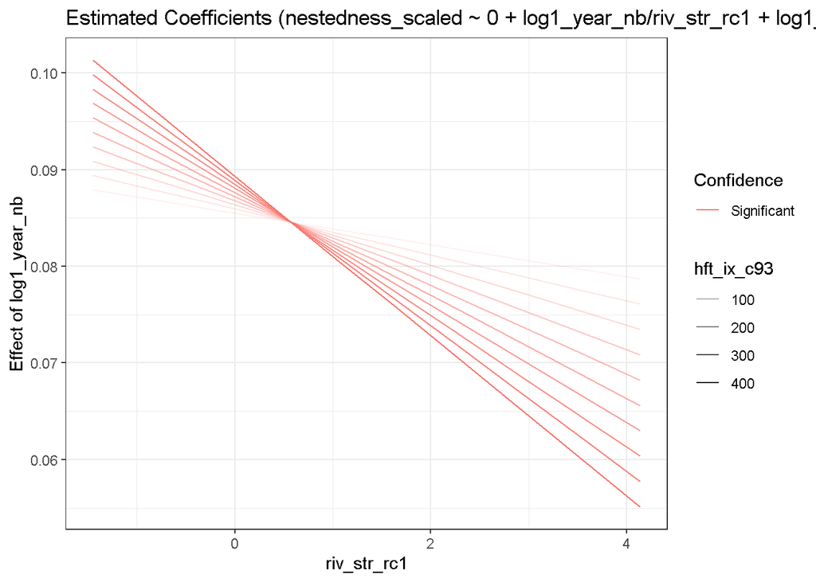

```r
jaccard <- gaussian_int_env$mod[[1]]
nestedness <- gaussian_int_env$mod[[3]]
slopes <- estimate_slopes(nestedness, trend = "log1_year_nb", at = c("riv_str_rc1",
    "hft_ix_c93"))
plot(slopes)
```

# 2 Heat map

# 3 Comparison drivers / no drivers model on random effects

- We compared the estimated temporal trends of sites in a model without drivers and with drivers in order to see the effect of the drivers.

We see that the estimations are very well correlated, while the model without drivers underestimate sometimes the estimated temporal trends.

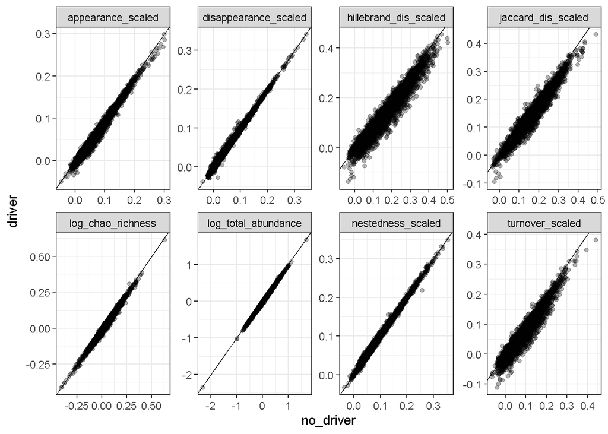

```r
tar_load(p_comp_site_tps_trends_drivers_tmb)
p_comp_site_tps_trends_drivers_tmb
```

# 4 Notes on transformed variables

- Notes:
  - [Back transform coefficients on scaled predictors](https://stackoverflow.com/a/47007597)
  - [Back transform coefficients on scaled predictors](https://stackoverflow.com/a/24286763)
  - [Back transform coefficients on scaled predictors](https://stackoverflow.com/a/53735644)
- [Interpreting coefficients on log scale](https://data.library.virginia.edu/interpreting-log-transformations-in-a-linear-model/):
  - Only the dependent/response variable is log-transformed: Exponentiate the coefficient, subtract one from this number, and multiply by 100. This gives the percent increase (or decrease) in the response for every one-unit increase in the independent variable. Example: the coefficient is 0.198. (exp(0.198) – 1) * 100 = 21.9. For every one-unit increase in the independent variable, our dependent variable increases by about 22%.
- Only independent/predictor variable(s) is log-transformed: Divide the coefficient by 100. This tells us that a 1% increase in the independent variable increases (or decreases) the dependent variable by (coefficient/100) units. Example: the coefficient is 0.198. 0.198/100 = 0.00198. For every 1% increase in the independent variable, our dependent variable increases by about 0.002. For x percent increase, multiply the coefficient by log(1.x). Example: For every 10% increase in the independent variable, our dependent variable increases by about 0.198 * log(1.10) = 0.02.
- Both dependent/response variable and independent/predictor variable(s) are log-transformed: Interpret the coefficient as the percent increase in the dependent variable for every 1% increase in the independent variable. Example: the coefficient is 0.198. For every 1% increase in the independent variable, our dependent variable increases by about 0.20%. For x percent increase, calculate 1.x to the power of the coefficient, subtract 1, and multiply by 100. Example: For every 20% increase in the independent variable, our dependent variable increases by about $(1.20^0.198 – 1) * 100$ = 3.7 percent.

# 5 Environmental variables

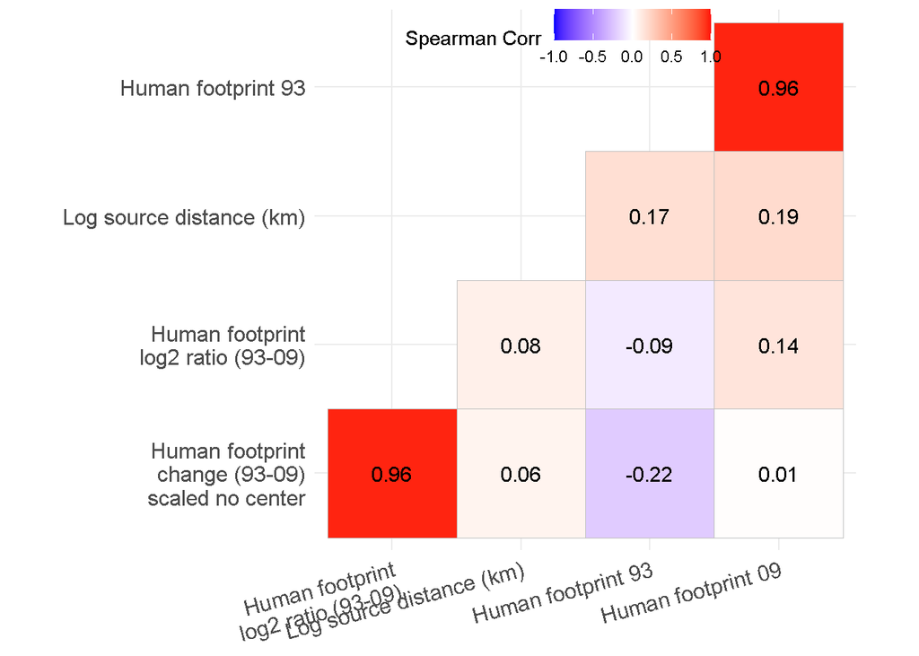

```r
cor_hft <- cor(analysis_dataset[,
    c("hft_c9309_scaled_no_center", "hft_ix_c9309_log2_ratio", "hft_ix_c93", "hft_ix_c09",
      "log_dist_up_km")
    ] %>%
      na.omit(),
  method = "spearman"
)
dimnames(cor_hft) <- map(
  dimnames(cor_hft),
  ~get_hft_riv_var()[.x]
)
ggcorrplot::ggcorrplot(
  cor_hft, hc.order = TRUE, type = "lower",
  lab = TRUE, tl.srt = 15, legend.title = "Spearman Corr") +
theme(legend.position = c(.45, .95), legend.direction = "horizontal") +
guides(colour = guide_legend(title.position = "top"))
```

# Heatmap cluster and multinomial model

```r
te <- expand.grid(
  list(
    cluster = c(seq_len(6)),
    response = clust_var
  )
)

avg_cl_var <- site_cl_rm %>%
  select(-riv_str_rc1, -hft_c9309_scaled_no_center) %>%
  pivot_longer(-c(siteid, cl),
    names_to = "response",
    values_to = "value") %>%
  group_by(cl, response) %>%
  summarise(value = median(value), .groups = "drop") %>%
  rename(cluster = cl)

# Ajouter moyenne par cluster
te <- te %>%
  left_join(avg_cl_var, by = c("cluster", "response"))

heat_map_df <- te %>%
  pivot_wider(names_from = "response", values_from = "value")
```

```r
cl_label <- c(
  "1: No change",
  "2: High turnover",
  "3: Increase of species richness",
  "4: Decrease of species richness",
  "5: Decrease of abundance",
  "6: Increase of abundance")
heat_cl <- te %>%
  ggplot(aes(
      x = get_var_replacement()[response],
      y = str_replace_all(as.character(cluster),
        setNames(cl_label, seq_len(6))),
      fill = value)) +
  geom_tile() +
  hrbrthemes::theme_ipsum(base_family = "Helvetica") +
  coord_fixed() +
  scale_fill_gradient2(
    high = muted("red"),
    mid = "white",
    low = muted("blue"),
    midpoint = 0,
    space = "Lab") +
  labs(x = "", y = "") +
  theme(axis.text.x = element_text(angle = 20, hjust = 1))
```

```r
# Build heatmap
site_cl_rm$cl <- relevel(as.factor(site_cl_rm$cl), ref = 1)

cl_mod <- nnet::multinom(
  cl ~ riv_str_rc1 + hft_c9309_scaled_no_center,
  data = site_cl_rm)
ci_cl_mod <- exp(confint(cl_mod)) - 1
exp_cl_mod <- exp(coef(cl_mod))
z_cl_mod <- summary(cl_mod)$coefficients / summary(cl_mod)$standard.errors


s_cl_mod <- map_dfr(list(exp_coef = exp_cl_mod, z = z_cl_mod),
  ~.x[, c("riv_str_rc1", "hft_c9309_scaled_no_center")] %>%
    as.data.frame() %>%
    rownames_to_column(var = "cluster"), .id = "type"
) %>%
  pivot_longer(c("riv_str_rc1", "hft_c9309_scaled_no_center"),
    names_to = "variable", values_to = "value") %>%
  pivot_wider(names_from = "type", values_from = "value") %>%
  mutate(pc = exp_coef - 1)
```

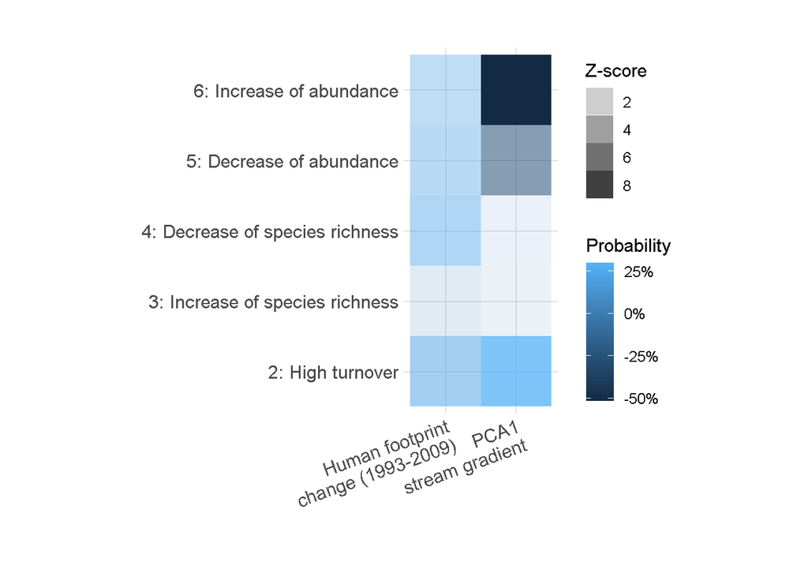

```r
p_cl_mod <- s_cl_mod %>%
  ggplot(aes(
      x = get_model_term_replacement()[variable],
      y = str_replace_all(as.character(cluster),
        setNames(cl_label, seq_len(6))),
      fill = pc
      )) +
  geom_tile(aes(alpha = abs(z))) +
  hrbrthemes::theme_ipsum(base_family = "Helvetica") +
  scale_fill_continuous(labels = scales::percent_format(accuracy = 1)) +
  coord_fixed() +
  labs(x = "", y = "", alpha = "Z-score", fill = "Probability") +
  theme(axis.text.x = element_text(angle = 20, hjust = 1))
p_cl_mod
```

# 6 Test model with short-long term changes

- There is no multicollinearity among variables
- Human footprint 1993 = lg term pressure / human footprint (1993-2009): short-term change

```r
# Check the presence of multicollinearity without interaction
chao_mod_hft93 <- glmmTMB(log_chao_richness ~
   log1_year_nb + riv_str_rc1 +
     hft_ix_c9309_log2_ratio +
    hft_ix_c93 +
    (1 + log1_year_nb | main_bas/siteid),
  modelling_data
)
check_collinearity(chao_mod_hft93)
```

|  | Term | VIF | SE_factor |
| --- | --- | --- | --- |
| 1 | log1_year_nb | 1.000028 | 1.000014 |
| 2 | riv_str_rc1 | 1.123028 | 1.059730 |
| 3 | hft_ix_c9309_log2_ratio | 1.001980 | 1.000989 |
| 4 | hft_ix_c93 | 1.124867 | 1.060597 |

- Model with interaction between HFT 93 and river structure:

```r
chao_mod_hft93_int_riv <- glmmTMB(log_chao_richness ~
   log1_year_nb * riv_str_rc1 +
    log1_year_nb * hft_ix_c9309_log2_ratio +
    log1_year_nb * hft_ix_c93 +
    log1_year_nb * hft_ix_c93 * riv_str_rc1 +
    (1 + log1_year_nb | main_bas/siteid),
  modelling_data
)
diagnose(chao_mod_hft93_int_riv)
```

```
#> model looks OK!
```

```r
summary(chao_mod_hft93_int_riv)
```

```
#>  Family: gaussian  ( identity )
#> Formula:
#> log_chao_richness ~ log1_year_nb * riv_str_rc1 + log1_year_nb *
#>     hft_ix_c9309_log2_ratio + log1_year_nb * hft_ix_c93 + log1_year_nb *
#>     hft_ix_c93 * riv_str_rc1 + (1 + log1_year_nb | main_bas/siteid)
#> Data: modelling_data
#>
#>      AIC      BIC   logLik deviance df.resid
#>  67187.5  67340.5 -33576.8  67153.5    59887
#>
#> Random effects:
#>
#> Conditional model:
#>  Groups          Name         Variance Std.Dev. Corr
#>  siteid:main_bas (Intercept)  0.287317 0.5360
#>                  log1_year_nb 0.013556 0.1164   -0.38
#>  main_bas        (Intercept)  0.291825 0.5402
#>                  log1_year_nb 0.005027 0.0709   -0.40
#>  Residual                     0.128253 0.3581
#> Number of obs: 59904, groups:  siteid:main_bas, 5359; main_bas, 315
#>
#> Dispersion estimate for gaussian family (sigma^2): 0.128
#>
#> Conditional model:
#>                                        Estimate Std. Error z value Pr(>|z|)
#> (Intercept)                           1.108e+00  4.086e-02  27.110  < 2e-16 ***
#> log1_year_nb                          1.154e-02  8.126e-03   1.421  0.15544
#> riv_str_rc1                           2.650e-01  1.770e-02  14.967  < 2e-16 ***
#> hft_ix_c9309_log2_ratio              -3.751e-02  3.084e-02  -1.216  0.22391
#> hft_ix_c93                            1.103e-03  1.154e-04   9.554  < 2e-16 ***
#> log1_year_nb:riv_str_rc1              7.221e-03  4.985e-03   1.449  0.14744
#> log1_year_nb:hft_ix_c9309_log2_ratio -5.959e-03  8.586e-03  -0.694  0.48765
#> log1_year_nb:hft_ix_c93               1.035e-04  3.153e-05   3.281  0.00103 **
#> riv_str_rc1:hft_ix_c93               -3.182e-04  7.723e-05  -4.120  3.8e-05 ***
#> log1_year_nb:riv_str_rc1:hft_ix_c93   5.310e-06  2.201e-05   0.241  0.80937
#> ---
#> Signif. codes:  0 '***' 0.001 '**' 0.01 '*' 0.05 '.' 0.1 ' ' 1
```

```r
chao_mod_hft93_dbl_int_riv <- glmmTMB(log_chao_richness ~
   log1_year_nb * riv_str_rc1 +
    log1_year_nb * hft_ix_c9309_log2_ratio +
    log1_year_nb * hft_ix_c93 +
    log1_year_nb * hft_ix_c93 * riv_str_rc1 +
    log1_year_nb * hft_ix_c9309_log2_ratio * riv_str_rc1 +
    (1 + log1_year_nb | main_bas/siteid),
  modelling_data
)
diagnose(chao_mod_hft93_dbl_int_riv)
```

```
#> model looks OK!
```

```r
summary(chao_mod_hft93_dbl_int_riv)
```

```
#>  Family: gaussian  ( identity )
#> Formula:
#> log_chao_richness ~ log1_year_nb * riv_str_rc1 + log1_year_nb *
#>     hft_ix_c9309_log2_ratio + log1_year_nb * hft_ix_c93 + log1_year_nb *
#>     hft_ix_c93 * riv_str_rc1 + log1_year_nb * hft_ix_c9309_log2_ratio *
#>     riv_str_rc1 + (1 + log1_year_nb | main_bas/siteid)
#> Data: modelling_data
#>
#>      AIC      BIC   logLik deviance df.resid
#>  67186.5  67357.6 -33574.3  67148.5    59885
#>
#> Random effects:
#>
#> Conditional model:
#>  Groups          Name         Variance Std.Dev. Corr
#>  siteid:main_bas (Intercept)  0.28729  0.53600
#>                  log1_year_nb 0.01354  0.11638  -0.38
#>  main_bas        (Intercept)  0.29204  0.54041
#>                  log1_year_nb 0.00493  0.07022  -0.40
#>  Residual                     0.12826  0.35813
#> Number of obs: 59904, groups:  siteid:main_bas, 5359; main_bas, 315
#>
#> Dispersion estimate for gaussian family (sigma^2): 0.128
#>
#> Conditional model:
#>                                                    Estimate Std. Error z value
#> (Intercept)                                       1.108e+00  4.088e-02  27.106
#> log1_year_nb                                      1.092e-02  8.102e-03   1.347
#> riv_str_rc1                                       2.656e-01  1.777e-02  14.945
#> hft_ix_c9309_log2_ratio                          -3.731e-02  3.084e-02  -1.210
#> hft_ix_c93                                        1.102e-03  1.155e-04   9.548
#> log1_year_nb:riv_str_rc1                          7.794e-03  4.994e-03   1.560
#> log1_year_nb:hft_ix_c9309_log2_ratio             -5.879e-03  8.579e-03  -0.685
#> log1_year_nb:hft_ix_c93                           1.053e-04  3.150e-05   3.342
#> riv_str_rc1:hft_ix_c93                           -3.180e-04  7.728e-05  -4.115
#> riv_str_rc1:hft_ix_c9309_log2_ratio               7.171e-03  2.711e-02   0.265
#> log1_year_nb:riv_str_rc1:hft_ix_c93               7.462e-06  2.203e-05   0.339
#> log1_year_nb:riv_str_rc1:hft_ix_c9309_log2_ratio  1.315e-02  7.500e-03   1.753
#>                                                  Pr(>|z|)
#> (Intercept)                                       < 2e-16 ***
#> log1_year_nb                                     0.177821
#> riv_str_rc1                                       < 2e-16 ***
#> hft_ix_c9309_log2_ratio                          0.226263
#> hft_ix_c93                                        < 2e-16 ***
#> log1_year_nb:riv_str_rc1                         0.118647
#> log1_year_nb:hft_ix_c9309_log2_ratio             0.493158
#> log1_year_nb:hft_ix_c93                          0.000832 ***
#> riv_str_rc1:hft_ix_c93                           3.88e-05 ***
#> riv_str_rc1:hft_ix_c9309_log2_ratio              0.791385
#> log1_year_nb:riv_str_rc1:hft_ix_c93              0.734804
#> log1_year_nb:riv_str_rc1:hft_ix_c9309_log2_ratio 0.079643 .
#> ---
#> Signif. codes:  0 '***' 0.001 '**' 0.01 '*' 0.05 '.' 0.1 ' ' 1
```

- Below I test how much interaction the model can evaluate
  - I show that the interaction among long-term, short-term changes of human footprint, stream gradient, and temporal trends (quadruple interaction) cannot be evaluated safely
  - However each triple interaction works!

```r
hb_mod <- glmmTMB(hillebrand_dis_scaled ~
  0 + log1_year_nb / riv_str_rc1 +
    log1_year_nb / hft_ix_c9309_log2_ratio +
    (0 + log1_year_nb | main_bas/siteid),
  modelling_data
)
summary(hb_mod)
```

```
#>  Family: gaussian  ( identity )
#> Formula:
#> hillebrand_dis_scaled ~ 0 + log1_year_nb/riv_str_rc1 + log1_year_nb/hft_ix_c9309_log2_ratio +
#>     (0 + log1_year_nb | main_bas/siteid)
#> Data: modelling_data
#>
#>      AIC      BIC   logLik deviance df.resid
#> -10470.1 -10416.1   5241.1 -10482.1    59898
#>
#> Random effects:
#>
#> Conditional model:
#>  Groups          Name         Variance Std.Dev.
#>  siteid:main_bas log1_year_nb 0.009649 0.09823
#>  main_bas        log1_year_nb 0.001763 0.04199
#>  Residual                     0.039025 0.19755
#> Number of obs: 59904, groups:  siteid:main_bas, 5359; main_bas, 315
#>
#> Dispersion estimate for gaussian family (sigma^2): 0.039
#>
#> Conditional model:
#>                                      Estimate Std. Error z value Pr(>|z|)
#> log1_year_nb                         0.162407   0.003450   47.08  < 2e-16 ***
#> log1_year_nb:riv_str_rc1             0.023422   0.001597   14.67  < 2e-16 ***
#> log1_year_nb:hft_ix_c9309_log2_ratio 0.020162   0.005047    4.00 6.47e-05 ***
#> ---
#> Signif. codes:  0 '***' 0.001 '**' 0.01 '*' 0.05 '.' 0.1 ' ' 1
```

```r
hb_mod_hft93 <- glmmTMB(hillebrand_dis_scaled ~
  0 + log1_year_nb / riv_str_rc1 +
    log1_year_nb / hft_ix_c9309_log2_ratio +
    log1_year_nb / hft_ix_c93 +
    log1_year_nb / hft_ix_c93:hft_ix_c9309_log2_ratio +
    log1_year_nb / hft_ix_c93:riv_str_rc1 +
    (0 + log1_year_nb | main_bas/siteid),
  modelling_data
)
summary(hb_mod_hft93)
```

```
#>  Family: gaussian  ( identity )
#> Formula:
#> hillebrand_dis_scaled ~ 0 + log1_year_nb/riv_str_rc1 + log1_year_nb/hft_ix_c9309_log2_ratio +
#>     log1_year_nb/hft_ix_c93 + log1_year_nb/hft_ix_c93:hft_ix_c9309_log2_ratio +
#>     log1_year_nb/hft_ix_c93:riv_str_rc1 + (0 + log1_year_nb |
#>     main_bas/siteid)
#> Data: modelling_data
#>
#>      AIC      BIC   logLik deviance df.resid
#> -10608.5 -10527.4   5313.2 -10626.5    59895
#>
#> Random effects:
#>
#> Conditional model:
#>  Groups          Name         Variance Std.Dev.
#>  siteid:main_bas log1_year_nb 0.009392 0.09691
#>  main_bas        log1_year_nb 0.001571 0.03964
#>  Residual                     0.039025 0.19755
#> Number of obs: 59904, groups:  siteid:main_bas, 5359; main_bas, 315
#>
#> Dispersion estimate for gaussian family (sigma^2): 0.039
#>
#> Conditional model:
#>                                                   Estimate Std. Error z value
#> log1_year_nb                                     1.283e-01  4.604e-03  27.867
#> log1_year_nb:riv_str_rc1                         2.098e-02  2.937e-03   7.146
#> log1_year_nb:hft_ix_c9309_log2_ratio            -1.135e-02  8.076e-03  -1.406
#> log1_year_nb:hft_ix_c93                          2.079e-04  1.803e-05  11.530
#> log1_year_nb:hft_ix_c9309_log2_ratio:hft_ix_c93  3.316e-04  6.200e-05   5.349
#> log1_year_nb:riv_str_rc1:hft_ix_c93             -1.413e-05  1.284e-05  -1.101
#>                                                 Pr(>|z|)
#> log1_year_nb                                     < 2e-16 ***
#> log1_year_nb:riv_str_rc1                        8.94e-13 ***
#> log1_year_nb:hft_ix_c9309_log2_ratio               0.160
#> log1_year_nb:hft_ix_c93                          < 2e-16 ***
#> log1_year_nb:hft_ix_c9309_log2_ratio:hft_ix_c93 8.86e-08 ***
#> log1_year_nb:riv_str_rc1:hft_ix_c93                0.271
#> ---
#> Signif. codes:  0 '***' 0.001 '**' 0.01 '*' 0.05 '.' 0.1 ' ' 1
```

```r
diagnose(hb_mod_hft93)
```

```
#> model looks OK!
```

```r
hb_mod_hft_full_int <- glmmTMB(hillebrand_dis_scaled ~
  0 + log1_year_nb / riv_str_rc1 +
    log1_year_nb / hft_ix_c9309_log2_ratio +
    log1_year_nb / hft_ix_c93 +
    log1_year_nb / hft_ix_c93:hft_ix_c9309_log2_ratio +
    log1_year_nb / hft_ix_c93:riv_str_rc1 +
    log1_year_nb / hft_ix_c9309_log2_ratio:riv_str_rc1 +
    log1_year_nb / hft_ix_c93:hft_ix_c9309_log2_ratio:riv_str_rc1 +
    (0 + log1_year_nb | main_bas/siteid),
  modelling_data
)
summary(hb_mod_hft_full_int)
```

```
#>  Family: gaussian  ( identity )
#> Formula:
#> hillebrand_dis_scaled ~ 0 + log1_year_nb/riv_str_rc1 + log1_year_nb/hft_ix_c9309_log2_ratio +
#>     log1_year_nb/hft_ix_c93 + log1_year_nb/hft_ix_c93:hft_ix_c9309_log2_ratio +
#>     log1_year_nb/hft_ix_c93:riv_str_rc1 + log1_year_nb/hft_ix_c9309_log2_ratio:riv_str_rc1 +
#>     log1_year_nb/hft_ix_c93:hft_ix_c9309_log2_ratio:riv_str_rc1 +
#>     (0 + log1_year_nb | main_bas/siteid)
#> Data: modelling_data
#>
#>      AIC      BIC   logLik deviance df.resid
#> -10605.3 -10506.3   5313.6 -10627.3    59893
#>
#> Random effects:
#>
#> Conditional model:
#>  Groups          Name         Variance Std.Dev.
#>  siteid:main_bas log1_year_nb 0.009389 0.0969
#>  main_bas        log1_year_nb 0.001576 0.0397
#>  Residual                     0.039025 0.1975
#> Number of obs: 59904, groups:  siteid:main_bas, 5359; main_bas, 315
#>
#> Dispersion estimate for gaussian family (sigma^2): 0.039
#>
#> Conditional model:
#>                                                               Estimate
#> log1_year_nb                                                 1.282e-01
#> log1_year_nb:riv_str_rc1                                     2.119e-02
#> log1_year_nb:hft_ix_c9309_log2_ratio                        -1.069e-02
#> log1_year_nb:hft_ix_c93                                      2.075e-04
#> log1_year_nb:hft_ix_c9309_log2_ratio:hft_ix_c93              3.242e-04
#> log1_year_nb:riv_str_rc1:hft_ix_c93                         -1.283e-05
#> log1_year_nb:riv_str_rc1:hft_ix_c9309_log2_ratio             7.625e-04
#> log1_year_nb:riv_str_rc1:hft_ix_c9309_log2_ratio:hft_ix_c93  2.486e-05
#>                                                             Std. Error z value
#> log1_year_nb                                                 4.611e-03  27.802
#> log1_year_nb:riv_str_rc1                                     2.946e-03   7.195
#> log1_year_nb:hft_ix_c9309_log2_ratio                         8.112e-03  -1.317
#> log1_year_nb:hft_ix_c93                                      1.806e-05  11.488
#> log1_year_nb:hft_ix_c9309_log2_ratio:hft_ix_c93              6.256e-05   5.183
#> log1_year_nb:riv_str_rc1:hft_ix_c93                          1.295e-05  -0.991
#> log1_year_nb:riv_str_rc1:hft_ix_c9309_log2_ratio             7.362e-03   0.104
#> log1_year_nb:riv_str_rc1:hft_ix_c9309_log2_ratio:hft_ix_c93  5.395e-05   0.461
#>                                                             Pr(>|z|)
#> log1_year_nb                                                 < 2e-16 ***
#> log1_year_nb:riv_str_rc1                                    6.24e-13 ***
#> log1_year_nb:hft_ix_c9309_log2_ratio                           0.188
#> log1_year_nb:hft_ix_c93                                      < 2e-16 ***
#> log1_year_nb:hft_ix_c9309_log2_ratio:hft_ix_c93             2.19e-07 ***
#> log1_year_nb:riv_str_rc1:hft_ix_c93                            0.322
#> log1_year_nb:riv_str_rc1:hft_ix_c9309_log2_ratio               0.918
#> log1_year_nb:riv_str_rc1:hft_ix_c9309_log2_ratio:hft_ix_c93    0.645
#> ---
#> Signif. codes:  0 '***' 0.001 '**' 0.01 '*' 0.05 '.' 0.1 ' ' 1
```

```r
diagnose(hb_mod_hft_full_int)
```

```
#> Unusually large Z-statistics (|x|>5):
#>
#> log1_year_nb:riv_str_rc1:hft_ix_c9309_log2_ratio
#>                                         9.654928
#>
#> Large Z-statistics (estimate/std err) suggest a failure of the Wald
#> approximation - often also associated with parameters that are at or
#> near the edge of their range (e.g. random-effects standard deviations
#> approaching 0).  While the Wald p-values and standard errors listed in
#> summary() are unreliable, profile confidence intervals (see
#> ?confint.glmmTMB) and likelihood ratio test p-values derived by
#> comparing models (e.g. ?drop1) may still be OK.  (Note that the LRT is
#> conservative when the null value is on the boundary, e.g. a variance or
#> zero-inflation value of 0 (Self and Liang 1987; Stram and Lee 1994;
#> Goldman and Whelan 2000); in simple cases the p-value is approximately
#> twice as large as it should be.)
```

```r
# Necessitate to delete the triple interaction?

chao_mod_hft_full_int <- glmmTMB(log_chao_richness ~
   log1_year_nb * riv_str_rc1 +
    log1_year_nb * hft_ix_c9309_log2_ratio +
    log1_year_nb * hft_ix_c93 +
    log1_year_nb:hft_ix_c93:hft_ix_c9309_log2_ratio +
    log1_year_nb:hft_ix_c93:riv_str_rc1 +
    log1_year_nb:hft_ix_c9309_log2_ratio:riv_str_rc1 +
    log1_year_nb:hft_ix_c93:hft_ix_c9309_log2_ratio:riv_str_rc1 +
    (1 + log1_year_nb | main_bas/siteid),
  modelling_data
)
diagnose(hb_mod_hft_full_int)
```

```
#> Unusually large Z-statistics (|x|>5):
#>
#> log1_year_nb:riv_str_rc1:hft_ix_c9309_log2_ratio
#>                                         9.654928
#>
#> Large Z-statistics (estimate/std err) suggest a failure of the Wald
#> approximation - often also associated with parameters that are at or
#> near the edge of their range (e.g. random-effects standard deviations
#> approaching 0).  While the Wald p-values and standard errors listed in
#> summary() are unreliable, profile confidence intervals (see
#> ?confint.glmmTMB) and likelihood ratio test p-values derived by
#> comparing models (e.g. ?drop1) may still be OK.  (Note that the LRT is
#> conservative when the null value is on the boundary, e.g. a variance or
#> zero-inflation value of 0 (Self and Liang 1987; Stram and Lee 1994;
#> Goldman and Whelan 2000); in simple cases the p-value is approximately
#> twice as large as it should be.)
```

```r
# Confirmed that we should remove the
summary(chao_mod_hft_full_int)
```

```
#>  Family: gaussian  ( identity )
#> Formula:
#> log_chao_richness ~ log1_year_nb * riv_str_rc1 + log1_year_nb *
#>     hft_ix_c9309_log2_ratio + log1_year_nb * hft_ix_c93 + log1_year_nb:hft_ix_c93:hft_ix_c9309_log2_ratio +
#>     log1_year_nb:hft_ix_c93:riv_str_rc1 + log1_year_nb:hft_ix_c9309_log2_ratio:riv_str_rc1 +
#>     log1_year_nb:hft_ix_c93:hft_ix_c9309_log2_ratio:riv_str_rc1 +
#>     (1 + log1_year_nb | main_bas/siteid)
#> Data: modelling_data
#>
#>      AIC      BIC   logLik deviance df.resid
#>  67199.2  67370.2 -33580.6  67161.2    59885
#>
#> Random effects:
#>
#> Conditional model:
#>  Groups          Name         Variance Std.Dev. Corr
#>  siteid:main_bas (Intercept)  0.288284 0.5369
#>                  log1_year_nb 0.013580 0.1165   -0.38
#>  main_bas        (Intercept)  0.296865 0.5449
#>                  log1_year_nb 0.004984 0.0706   -0.41
#>  Residual                     0.128259 0.3581
#> Number of obs: 59904, groups:  siteid:main_bas, 5359; main_bas, 315
#>
#> Dispersion estimate for gaussian family (sigma^2): 0.128
#>
#> Conditional model:
#>                                                               Estimate
#> (Intercept)                                                  1.120e+00
#> log1_year_nb                                                 9.288e-03
#> riv_str_rc1                                                  2.052e-01
#> hft_ix_c9309_log2_ratio                                     -4.032e-02
#> hft_ix_c93                                                   1.021e-03
#> log1_year_nb:riv_str_rc1                                     1.671e-02
#> log1_year_nb:hft_ix_c9309_log2_ratio                        -1.500e-02
#> log1_year_nb:hft_ix_c93                                      1.233e-04
#> log1_year_nb:hft_ix_c9309_log2_ratio:hft_ix_c93              1.023e-04
#> log1_year_nb:riv_str_rc1:hft_ix_c93                         -4.646e-05
#> log1_year_nb:riv_str_rc1:hft_ix_c9309_log2_ratio             2.889e-02
#> log1_year_nb:riv_str_rc1:hft_ix_c9309_log2_ratio:hft_ix_c93 -1.450e-04
#>                                                             Std. Error z value
```

[output cut: 12 more lines]

```
#>                                                             Pr(>|z|)
#> (Intercept)                                                  < 2e-16 ***
#> log1_year_nb                                                0.252576
#> riv_str_rc1                                                  < 2e-16 ***
#> hft_ix_c9309_log2_ratio                                     0.191633
#> hft_ix_c93                                                   < 2e-16 ***
#> log1_year_nb:riv_str_rc1                                    0.000208 ***
#> log1_year_nb:hft_ix_c9309_log2_ratio                        0.237277
#> log1_year_nb:hft_ix_c93                                     0.000105 ***
#> log1_year_nb:hft_ix_c9309_log2_ratio:hft_ix_c93             0.267114
#> log1_year_nb:riv_str_rc1:hft_ix_c93                         0.014363 *
#> log1_year_nb:riv_str_rc1:hft_ix_c9309_log2_ratio            0.005427 **
#> log1_year_nb:riv_str_rc1:hft_ix_c9309_log2_ratio:hft_ix_c93 0.058020 .
#> ---
#> Signif. codes:  0 '***' 0.001 '**' 0.01 '*' 0.05 '.' 0.1 ' ' 1
```

```r
check_collinearity(chao_mod_hft_full_int)
```

|  | Term | VIF | SE_factor |
| --- | --- | --- | --- |
| 1 | log1_year_nb | 7.493403 | 2.737408 |
| 2 | riv_str_rc1 | 3.018483 | 1.737378 |
| 3 | hft_ix_c9309_log2_ratio | 1.394699 | 1.180974 |
| 4 | hft_ix_c93 | 3.275247 | 1.809764 |
| 5 | log1_year_nb:riv_str_rc1 | 16.869724 | 4.107277 |
| 6 | log1_year_nb:hft_ix_c9309_log2_ratio | 3.641722 | 1.908330 |
| 7 | log1_year_nb:hft_ix_c93 | 12.226213 | 3.496600 |
| 8 | log1_year_nb:hft_ix_c9309_log2_ratio:hft_ix_c93 | 4.285905 | 2.070243 |
| 9 | log1_year_nb:riv_str_rc1:hft_ix_c93 | 15.673984 | 3.959038 |
| 10 | log1_year_nb:riv_str_rc1:hft_ix_c9309_log2_ratio | 3.470434 | 1.862910 |

[output cut: 1 more lines]

```r
hb_mod_hft_int_ok <- glmmTMB(hillebrand_dis_scaled ~
  0 + log1_year_nb / riv_str_rc1 +
    log1_year_nb / hft_ix_c9309_log2_ratio +
    log1_year_nb / hft_ix_c93 +
    log1_year_nb / hft_ix_c93:hft_ix_c9309_log2_ratio +
    log1_year_nb / hft_ix_c93:riv_str_rc1 +
    log1_year_nb / hft_ix_c9309_log2_ratio:riv_str_rc1 +
    (0 + log1_year_nb | main_bas/siteid),
  modelling_data
)
diagnose(hb_mod_hft_int_ok)
```

```
#> model looks OK!
```

```r
summary(hb_mod_hft_int_ok)
```

```
#>  Family: gaussian  ( identity )
#> Formula:
#> hillebrand_dis_scaled ~ 0 + log1_year_nb/riv_str_rc1 + log1_year_nb/hft_ix_c9309_log2_ratio +
#>     log1_year_nb/hft_ix_c93 + log1_year_nb/hft_ix_c93:hft_ix_c9309_log2_ratio +
#>     log1_year_nb/hft_ix_c93:riv_str_rc1 + log1_year_nb/hft_ix_c9309_log2_ratio:riv_str_rc1 +
#>     (0 + log1_year_nb | main_bas/siteid)
#> Data: modelling_data
#>
#>      AIC      BIC   logLik deviance df.resid
#> -10607.1 -10517.0   5313.5 -10627.1    59894
#>
#> Random effects:
#>
#> Conditional model:
#>  Groups          Name         Variance Std.Dev.
#>  siteid:main_bas log1_year_nb 0.009390 0.09690
#>  main_bas        log1_year_nb 0.001573 0.03967
#>  Residual                     0.039025 0.19755
#> Number of obs: 59904, groups:  siteid:main_bas, 5359; main_bas, 315
#>
#> Dispersion estimate for gaussian family (sigma^2): 0.039
#>
#> Conditional model:
#>                                                    Estimate Std. Error z value
#> log1_year_nb                                      1.282e-01  4.609e-03  27.808
#> log1_year_nb:riv_str_rc1                          2.112e-02  2.941e-03   7.181
#> log1_year_nb:hft_ix_c9309_log2_ratio             -1.078e-02  8.109e-03  -1.330
#> log1_year_nb:hft_ix_c93                           2.080e-04  1.803e-05  11.534
#> log1_year_nb:hft_ix_c9309_log2_ratio:hft_ix_c93   3.266e-04  6.233e-05   5.241
#> log1_year_nb:riv_str_rc1:hft_ix_c93              -1.351e-05  1.286e-05  -1.051
#> log1_year_nb:riv_str_rc1:hft_ix_c9309_log2_ratio  3.458e-03  4.470e-03   0.774
#>                                                  Pr(>|z|)
#> log1_year_nb                                      < 2e-16 ***
#> log1_year_nb:riv_str_rc1                         6.93e-13 ***
#> log1_year_nb:hft_ix_c9309_log2_ratio                0.184
#> log1_year_nb:hft_ix_c93                           < 2e-16 ***
#> log1_year_nb:hft_ix_c9309_log2_ratio:hft_ix_c93  1.60e-07 ***
#> log1_year_nb:riv_str_rc1:hft_ix_c93                 0.293
#> log1_year_nb:riv_str_rc1:hft_ix_c9309_log2_ratio    0.439
#> ---
#> Signif. codes:  0 '***' 0.001 '**' 0.01 '*' 0.05 '.' 0.1 ' ' 1
```

```r
chao_mod_hft_int_ok <- glmmTMB(log_chao_richness ~
   log1_year_nb * riv_str_rc1 +
    log1_year_nb * hft_ix_c9309_log2_ratio +
    log1_year_nb * hft_ix_c93 +
    log1_year_nb:hft_ix_c93:hft_ix_c9309_log2_ratio +
    log1_year_nb:hft_ix_c93:riv_str_rc1 +
    log1_year_nb:hft_ix_c9309_log2_ratio:riv_str_rc1 +
    (1 + log1_year_nb | main_bas/siteid),
  modelling_data
)
diagnose(chao_mod_hft_int_ok)
```

```
#> model looks OK!
```

```r
# Confirmed that we should remove the
summary(chao_mod_hft_int_ok)
```

```
#>  Family: gaussian  ( identity )
#> Formula:
#> log_chao_richness ~ log1_year_nb * riv_str_rc1 + log1_year_nb *
#>     hft_ix_c9309_log2_ratio + log1_year_nb * hft_ix_c93 + log1_year_nb:hft_ix_c93:hft_ix_c9309_log2_ratio +
#>     log1_year_nb:hft_ix_c93:riv_str_rc1 + log1_year_nb:hft_ix_c9309_log2_ratio:riv_str_rc1 +
#>     (1 + log1_year_nb | main_bas/siteid)
#> Data: modelling_data
#>
#>      AIC      BIC   logLik deviance df.resid
#>  67200.8  67362.8 -33582.4  67164.8    59886
#>
#> Random effects:
#>
#> Conditional model:
#>  Groups          Name         Variance Std.Dev. Corr
#>  siteid:main_bas (Intercept)  0.288370 0.53700
#>                  log1_year_nb 0.013603 0.11663  -0.38
#>  main_bas        (Intercept)  0.296789 0.54478
#>                  log1_year_nb 0.004962 0.07044  -0.41
#>  Residual                     0.128254 0.35813
#> Number of obs: 59904, groups:  siteid:main_bas, 5359; main_bas, 315
#>
#> Dispersion estimate for gaussian family (sigma^2): 0.128
#>
#> Conditional model:
#>                                                    Estimate Std. Error z value
#> (Intercept)                                       1.120e+00  4.100e-02  27.322
#> log1_year_nb                                      9.480e-03  8.111e-03   1.169
#> riv_str_rc1                                       2.051e-01  1.009e-02  20.323
#> hft_ix_c9309_log2_ratio                          -4.077e-02  3.088e-02  -1.320
#> hft_ix_c93                                        1.022e-03  1.141e-04   8.953
#> log1_year_nb:riv_str_rc1                          1.698e-02  4.504e-03   3.771
#> log1_year_nb:hft_ix_c9309_log2_ratio             -1.390e-02  1.268e-02  -1.096
#> log1_year_nb:hft_ix_c93                           1.204e-04  3.176e-05   3.790
#> log1_year_nb:hft_ix_c9309_log2_ratio:hft_ix_c93   8.297e-05  9.166e-05   0.905
#> log1_year_nb:riv_str_rc1:hft_ix_c93              -4.149e-05  1.881e-05  -2.206
#> log1_year_nb:riv_str_rc1:hft_ix_c9309_log2_ratio  1.342e-02  6.431e-03   2.086
#>                                                  Pr(>|z|)
#> (Intercept)                                       < 2e-16 ***
#> log1_year_nb                                     0.242453
#> riv_str_rc1                                       < 2e-16 ***
#> hft_ix_c9309_log2_ratio                          0.186716
#> hft_ix_c93                                        < 2e-16 ***
#> log1_year_nb:riv_str_rc1                         0.000163 ***
#> log1_year_nb:hft_ix_c9309_log2_ratio             0.273043
#> log1_year_nb:hft_ix_c93                          0.000151 ***
#> log1_year_nb:hft_ix_c9309_log2_ratio:hft_ix_c93  0.365344
#> log1_year_nb:riv_str_rc1:hft_ix_c93              0.027365 *
#> log1_year_nb:riv_str_rc1:hft_ix_c9309_log2_ratio 0.036942 *
#> ---
#> Signif. codes:  0 '***' 0.001 '**' 0.01 '*' 0.05 '.' 0.1 ' ' 1
```

```r
hb_mod_hft_scaled_int_ok <- glmmTMB(hillebrand_dis_scaled ~
  0 + log1_year_nb / riv_str_rc1 +
    log1_year_nb / hft_c9309_scaled_no_center +
    log1_year_nb / hft_ix_c93 +
    log1_year_nb / hft_ix_c93:hft_c9309_scaled_no_center +
    log1_year_nb / hft_ix_c93:riv_str_rc1 +
    log1_year_nb / hft_c9309_scaled_no_center:riv_str_rc1 +
    (0 + log1_year_nb | main_bas/siteid),
  modelling_data
)
diagnose(hb_mod_hft_int_ok)
```

```
#> model looks OK!
```

```r
summary(hb_mod_hft_int_ok)
```

```
#>  Family: gaussian  ( identity )
#> Formula:
#> hillebrand_dis_scaled ~ 0 + log1_year_nb/riv_str_rc1 + log1_year_nb/hft_ix_c9309_log2_ratio +
#>     log1_year_nb/hft_ix_c93 + log1_year_nb/hft_ix_c93:hft_ix_c9309_log2_ratio +
#>     log1_year_nb/hft_ix_c93:riv_str_rc1 + log1_year_nb/hft_ix_c9309_log2_ratio:riv_str_rc1 +
#>     (0 + log1_year_nb | main_bas/siteid)
#> Data: modelling_data
#>
#>      AIC      BIC   logLik deviance df.resid
#> -10607.1 -10517.0   5313.5 -10627.1    59894
#>
#> Random effects:
#>
#> Conditional model:
#>  Groups          Name         Variance Std.Dev.
#>  siteid:main_bas log1_year_nb 0.009390 0.09690
#>  main_bas        log1_year_nb 0.001573 0.03967
#>  Residual                     0.039025 0.19755
#> Number of obs: 59904, groups:  siteid:main_bas, 5359; main_bas, 315
#>
#> Dispersion estimate for gaussian family (sigma^2): 0.039
#>
#> Conditional model:
#>                                                    Estimate Std. Error z value
#> log1_year_nb                                      1.282e-01  4.609e-03  27.808
#> log1_year_nb:riv_str_rc1                          2.112e-02  2.941e-03   7.181
#> log1_year_nb:hft_ix_c9309_log2_ratio             -1.078e-02  8.109e-03  -1.330
#> log1_year_nb:hft_ix_c93                           2.080e-04  1.803e-05  11.534
#> log1_year_nb:hft_ix_c9309_log2_ratio:hft_ix_c93   3.266e-04  6.233e-05   5.241
#> log1_year_nb:riv_str_rc1:hft_ix_c93              -1.351e-05  1.286e-05  -1.051
#> log1_year_nb:riv_str_rc1:hft_ix_c9309_log2_ratio  3.458e-03  4.470e-03   0.774
#>                                                  Pr(>|z|)
#> log1_year_nb                                      < 2e-16 ***
#> log1_year_nb:riv_str_rc1                         6.93e-13 ***
#> log1_year_nb:hft_ix_c9309_log2_ratio                0.184
#> log1_year_nb:hft_ix_c93                           < 2e-16 ***
#> log1_year_nb:hft_ix_c9309_log2_ratio:hft_ix_c93  1.60e-07 ***
#> log1_year_nb:riv_str_rc1:hft_ix_c93                 0.293
#> log1_year_nb:riv_str_rc1:hft_ix_c9309_log2_ratio    0.439
#> ---
#> Signif. codes:  0 '***' 0.001 '**' 0.01 '*' 0.05 '.' 0.1 ' ' 1
```

```r
compare_parameters(hb_mod_hft_int_ok, hb_mod_hft_scaled_int_ok)
```

|  | Parameter | Component | Coefficient.hb_mod_hft_int_ok | SE.hb_mod_hft_int_ok | CI.hb_mod_hft_int_ok | CI_low.hb_mod_hft_int_ok | CI_high.hb_mod_hft_int_ok | z.hb_mod_hft_int_ok | df_error.hb_mod_hft_int_ok | p.hb_mod_hft_int_ok | Effects.hb_mod_hft_int_ok | Coefficient.hb_mod_hft_scaled_int_ok | SE.hb_mod_hft_scaled_int_ok | CI.hb_mod_hft_scaled_int_ok | CI_low.hb_mod_hft_scaled_int_ok | CI_high.hb_mod_hft_scaled_int_ok | z.hb_mod_hft_scaled_int_ok | df_error.hb_mod_hft_scaled_int_ok | p.hb_mod_hft_scaled_int_ok | Effects.hb_mod_hft_scaled_int_ok |
| --- | --- | --- | --- | --- | --- | --- | --- | --- | --- | --- | --- | --- | --- | --- | --- | --- | --- | --- | --- | --- |
| 1 | log1 year nb | conditional | 1.281660e-01 | 4.609042e-03 | 0.95 | 1.191324e-01 | 1.371996e-01 | 27.8075101 | Inf | 3.519328e-170 | fixed | 1.267418e-01 | 4.602228e-03 | 0.95 | 1.177216e-01 | 1.357620e-01 | 27.5392269 | Inf | 5.956502e-167 | fixed |
| 2 | log1 year nb * riv str rc1 | conditional | 2.111975e-02 | 2.941112e-03 | 0.95 | 1.535528e-02 | 2.688423e-02 | 7.1808740 | Inf | 6.926716e-13 | fixed | 2.082305e-02 | 2.933862e-03 | 0.95 | 1.507278e-02 | 2.657331e-02 | 7.0974862 | Inf | 1.270465e-12 | fixed |
| 3 | log1 year nb * hft ix c93 | conditional | 2.080039e-04 | 1.803346e-05 | 0.95 | 1.726590e-04 | 2.433489e-04 | 11.5343304 | Inf | 8.857367e-31 | fixed | 2.120998e-04 | 1.830670e-05 | 0.95 | 1.762193e-04 | 2.479802e-04 | 11.5859082 | Inf | 4.857903e-31 | fixed |
| 4 | log1 year nb * riv str rc1 * hft ix c93 | conditional | -1.351373e-05 | 1.286358e-05 | 0.95 | -3.872589e-05 | 1.169843e-05 | -1.0505415 | Inf | 2.934692e-01 | fixed | -1.143716e-05 | 1.296637e-05 | 0.95 | -3.685077e-05 | 1.397646e-05 | -0.8820634 | Inf | 3.777425e-01 | fixed |
| 5 | log1 year nb * hft ix c9309 log2 ratio | conditional | -1.078378e-02 | 8.109150e-03 | 0.95 | -2.667742e-02 | 5.109863e-03 | -1.3298285 | Inf | 1.835748e-01 | fixed | NA | NA | NA | NA | NA | NA | NA | NA | NA |
| 6 | log1 year nb * hft ix c9309 log2 ratio * hft ix c93 | conditional | 3.266417e-04 | 6.232769e-05 | 0.95 | 2.044817e-04 | 4.488017e-04 | 5.2407154 | Inf | 1.599552e-07 | fixed | NA | NA | NA | NA | NA | NA | NA | NA | NA |
| 7 | log1 year nb * riv str rc1 * hft ix c9309 log2 ratio | conditional | 3.458176e-03 | 4.470005e-03 | 0.95 | -5.302873e-03 | 1.221922e-02 | 0.7736402 | Inf | 4.391436e-01 | fixed | NA | NA | NA | NA | NA | NA | NA | NA | NA |
| 8 | log1 year nb * hft c9309 scaled no center | conditional | NA | NA | NA | NA | NA | NA | NA | NA | NA | 6.007520e-03 | 4.171332e-03 | 0.95 | -2.168141e-03 | 1.418318e-02 | 1.4401922 | Inf | 1.498130e-01 | fixed |
| 9 | log1 year nb * hft c9309 scaled no center * hft ix c93 | conditional | NA | NA | NA | NA | NA | NA | NA | NA | NA | 3.001134e-05 | 1.920348e-05 | 0.95 | -7.626781e-06 | 6.764946e-05 | 1.5628077 | Inf | 1.180978e-01 | fixed |
| 10 | log1 year nb * riv str rc1 * hft c9309 scaled no center | conditional | NA | NA | NA | NA | NA | NA | NA | NA | NA | 1.211140e-03 | 1.480914e-03 | 0.95 | -1.691397e-03 | 4.113678e-03 | 0.8178331 | Inf | 4.134525e-01 | fixed |

# 7 Assess if log-year or year is the best model

Logging the year number is a way to linearize the relationship between dissimilarity and year, which looks like a Michaelis-Menten relationship. With the complete model, we can compare the fitting of the model with year or log_year.

```r
#,
#   p_pred_obs = map(mod, plot_pred_obs_glmmtmb)
```

```r
biodiv_facets_main <- c(abun_var, var_jaccard, rich_var)[
  !str_detect(
    c(abun_var, var_jaccard, rich_var),
    "species_nb|tps|abundance_scaled|^total"
    )
  ]
```

- Model without random effect on ecological drivers, the more complex models having many convergence problems :

```r
comp_log_year_no_evt_re <- binded_gaussian_tmb_no_evt_re %>%
  filter(response %in% biodiv_facets_main) %>%
  mutate(
    fit_summary = map(mod, broom.mixed::glance)
  )
```

- Model year as log has a lower AIC except for total abundance and evenness_scaled. The difference of AIC is spectacular for jaccard and hillebrand.

```r
aic_table_no_evt_re <- comp_log_year_no_evt_re %>%
  select(year_var, response, fit_summary) %>%
  unnest(fit_summary) %>%
  select(year_var, response, AIC) %>%
  mutate( AIC = round(AIC)) %>%
  pivot_wider(names_from = "year_var", values_from = "AIC") %>%
  mutate(which_min = ifelse(
      log1_year_nb == min(c(year_nb, log1_year_nb)),
        "log1_year_nb", "year_nb")
  )
aic_table_no_evt_re
```

| response | year_nb | log1_year_nb | which_min |
| --- | --- | --- | --- |
| chao_richness | 281492 | 281257 | NA |
| jaccard_dis_scaled | -21492 | -30846 | NA |
| turnover_scaled | -23296 | NA | NA |
| nestedness_scaled | -31933 | -34971 | NA |
| hillebrand_dis_scaled | -5720 | -12805 | NA |
| appearance_scaled | -78449 | -81625 | NA |
| disappearance_scaled | -100594 | NA | NA |
| evenness_scaled | -11241 | -11149 | NA |
| log_total_abundance | 159541 | 159633 | NA |

## 7.1 Compare models

- Actually, there are nothing to compare since the other models fails to have an AIC because the random effect are badly estimated.

```r
model_to_compare <- binded_gaussian_tmb_no_evt_re %>%
  filter(year_var == "log1_year_nb", response %in% biodiv_facets_main)
```

```r
model_to_compare <- model_to_compare %>%
  mutate(diagnosis = map_lgl(mod, diagnose))
```

```
#> model looks OK!
#> Unusually large coefficients (|x|>10):
#>
#> theta_1+log1_year_nb|main_bas:siteid.3
#>                               477.8956
#>
#> Large negative coefficients in zi (log-odds of zero-inflation),
#> dispersion, or random effects (log-standard deviations) suggest
#> unnecessary components (converging to zero on the constrained scale);
#> large negative and/or positive components in binomial or Poisson
#> conditional parameters suggest (quasi-)complete separation
#> Warning in sqrt(diag(object$cov.fixed)): NaNs produced
#> Unusually large coefficients (|x|>10):
#>
#> theta_1+log1_year_nb|main_bas:siteid.3
#>                               550.1411
#>
#> Large negative coefficients in zi (log-odds of zero-inflation),
#> dispersion, or random effects (log-standard deviations) suggest
#> unnecessary components (converging to zero on the constrained scale);
#> large negative and/or positive components in binomial or Poisson
#> conditional parameters suggest (quasi-)complete separation
#>
#>
#> Non-positive definite Hessian
#>
#> The Hessian matrix represents the curvature of the log-likelihood
#> surface at the maximum likelihood estimate (MLE) of the parameters (its
#> inverse is the estimate of the parameter covariance matrix).  A
#> non-positive-definite Hessian means that the likelihood surface is
#> approximately flat (or upward-curving) at the MLE, which means the
#> model is overfitted or poorly posed in some way.
#>
#>
#> parameters with non-finite standard deviations:
#> theta_1+log1_year_nb|main_bas:siteid.3
#>
#>
#>
#> The next set of diagnostics attempts to determine which elements of the
```

[output cut: 94 more lines]

```
#>
#> log1_year_nb:unitabundanceInd.100m2
#>                            29.64645
#>
#> Large Z-statistics (estimate/std err) suggest a failure of the Wald
#> approximation - often also associated with parameters that are at or
#> near the edge of their range (e.g. random-effects standard deviations
#> approaching 0).  While the Wald p-values and standard errors listed in
#> summary() are unreliable, profile confidence intervals (see
#> ?confint.glmmTMB) and likelihood ratio test p-values derived by
#> comparing models (e.g. ?drop1) may still be OK.  (Note that the LRT is
#> conservative when the null value is on the boundary, e.g. a variance or
#> zero-inflation value of 0 (Self and Liang 1987; Stram and Lee 1994;
#> Goldman and Whelan 2000); in simple cases the p-value is approximately
#> twice as large as it should be.)
```

- The site random effect on the intercept is producing problems:

```r
x <- model_to_compare$mod[[2]]
diagnose(x)
```

```
#> Unusually large coefficients (|x|>10):
#>
#> theta_1+log1_year_nb|main_bas:siteid.3
#>                               477.8956
#>
#> Large negative coefficients in zi (log-odds of zero-inflation),
#> dispersion, or random effects (log-standard deviations) suggest
#> unnecessary components (converging to zero on the constrained scale);
#> large negative and/or positive components in binomial or Poisson
#> conditional parameters suggest (quasi-)complete separation
```

```r
model_parameters(x)
```

| Parameter | Coefficient | SE | CI | CI_low | CI_high | z | df_error | p | Effects | Group | Component |
| --- | --- | --- | --- | --- | --- | --- | --- | --- | --- | --- | --- |
| (Intercept) | 0.102297934 | 0.004836862 | 0.95 | 0.0928178598 | 0.111778009 | 21.149651 | Inf | 2.779894e-99 | fixed |  | conditional |
| log1_year_nb | 0.121072921 | 0.002635268 | 0.95 | 0.1159078909 | 0.126237951 | 45.943310 | Inf | 0.000000e+00 | fixed |  | conditional |
| riv_str_rc1 | 0.023149673 | 0.002084056 | 0.95 | 0.0190649982 | 0.027234348 | 11.107990 | Inf | 1.147130e-28 | fixed |  | conditional |
| hft_ix_c9309_diff_scaled | 0.012247982 | 0.002263702 | 0.95 | 0.0078112086 | 0.016684756 | 5.410599 | Inf | 6.281424e-08 | fixed |  | conditional |
| log1_year_nb:riv_str_rc1 | 0.005129376 | 0.001264716 | 0.95 | 0.0026505782 | 0.007608173 | 4.055753 | Inf | 4.997296e-05 | fixed |  | conditional |
| log1_year_nb:hft_ix_c9309_diff_scaled | 0.003280402 | 0.001355542 | 0.95 | 0.0006235891 | 0.005937216 | 2.419993 | Inf | 1.552079e-02 | fixed |  | conditional |
| SD (Intercept) | 0.042366133 | NA | 0.95 | NA | NA | NA | NA | NA | random | main_bas:siteid | conditional |
| SD (Intercept) | 0.062397180 | NA | 0.95 | NA | NA | NA | NA | NA | random | main_bas | conditional |
| SD (:siteid) | 0.056398108 | NA | 0.95 | NA | NA | NA | NA | NA | random | main_bas | conditional |
| SD (log1_year_nb) | 0.031771527 | NA | 0.95 | NA | NA | NA | NA | NA | random | main_bas | conditional |

[output cut: 3 more lines]

```r
comp_jac <- tps_model_for_comp[tps_model_for_comp$response == "jaccard_dis_scaled",]$mod[[1]]

y <- update(x,
  formula = jaccard_dis_scaled ~ log1_year_nb * riv_str_rc1 + log1_year_nb *
    hft_ix_c9309_diff_scaled + (1 | main_bas/siteid)
  )
diagnose(y)
```

```
#> model looks OK!
```

```r
#May be that the weak variation of log year nb is responsible
z <- update(x,
  formula = jaccard_dis_scaled ~
    scale(log1_year_nb) * riv_str_rc1 +
    scale(log1_year_nb) * hft_ix_c9309_diff_scaled +
    (1 + scale(log1_year_nb) | main_bas/siteid)
  )
diagnose(z)
```

```
#> Unusually large coefficients (|x|>10):
#>
#> theta_1+scale(log1_year_nb)|siteid:main_bas.3
#>                                      1008.933
#>
#> Large negative coefficients in zi (log-odds of zero-inflation),
#> dispersion, or random effects (log-standard deviations) suggest
#> unnecessary components (converging to zero on the constrained scale);
#> large negative and/or positive components in binomial or Poisson
#> conditional parameters suggest (quasi-)complete separation
```

```r
#no

za <- update(x,
  formula = jaccard_dis_scaled ~
    scale(log1_year_nb) * riv_str_rc1 +
    scale(log1_year_nb) * hft_ix_c9309_diff_scaled +
    (scale(log1_year_nb) | main_bas/siteid)
  )
diagnose(za)
```

```
#> Unusually large coefficients (|x|>10):
#>
#> theta_scale(log1_year_nb)|siteid:main_bas.3
#>                                    1008.933
#>
#> Large negative coefficients in zi (log-odds of zero-inflation),
#> dispersion, or random effects (log-standard deviations) suggest
#> unnecessary components (converging to zero on the constrained scale);
#> large negative and/or positive components in binomial or Poisson
#> conditional parameters suggest (quasi-)complete separation
```

```r
zb <- update(x,
  formula = jaccard_dis_scaled ~
    log1_year_nb * riv_str_rc1 +
    log1_year_nb * hft_ix_c9309_diff_scaled +
    (1 | main_bas/siteid)
)
diagnose(zb)
```

```
#> model looks OK!
```

```r
zc <- comp_jac[["main0"]]

diagnose(zc)
```

```
#> model looks OK!
```

```r
parameters(zc)
```

| Parameter | Coefficient | SE | CI | CI_low | CI_high | z | df_error | p | Effects | Group | Component |
| --- | --- | --- | --- | --- | --- | --- | --- | --- | --- | --- | --- |
| log1_year_nb | 0.168901198 | 0.002865727 | 0.95 | 0.1632844754 | 0.174517920 | 58.938337 | Inf | 0.000000e+00 | fixed |  | conditional |
| riv_str_rc1 | 0.028822374 | 0.001797670 | 0.95 | 0.0252990064 | 0.032345742 | 16.033187 | Inf | 7.493834e-58 | fixed |  | conditional |
| hft_c9309_scaled_no_center | -0.016699406 | 0.001813929 | 0.95 | -0.0202546418 | -0.013144171 | -9.206207 | Inf | 3.378528e-20 | fixed |  | conditional |
| log1_year_nb:riv_str_rc1 | 0.002696287 | 0.001457482 | 0.95 | -0.0001603251 | 0.005552898 | 1.849963 | Inf | 6.431895e-02 | fixed |  | conditional |
| log1_year_nb:hft_c9309_scaled_no_center | 0.017057612 | 0.001623787 | 0.95 | 0.0138750488 | 0.020240175 | 10.504836 | Inf | 8.206496e-26 | fixed |  | conditional |
| SD (log1_year_nb) | 0.075218525 | NA | 0.95 | 0.0735353729 | 0.076940202 | NA | NA | NA | random | siteid:main_bas | conditional |
| SD (log1_year_nb) | 0.035873026 | NA | 0.95 | 0.0308059282 | 0.041773584 | NA | NA | NA | random | main_bas | conditional |
| SD (Observations) | 0.174505705 | NA | 0.95 | 0.1734718608 | 0.175545710 | NA | NA | NA | random | Residual | conditional |

```r
confint(zc)
```

```
#>                                                      2.5 %       97.5 %
#> cond.log1_year_nb                             0.1632844754  0.174517920
#> cond.riv_str_rc1                              0.0252990064  0.032345742
#> cond.hft_c9309_scaled_no_center              -0.0202546418 -0.013144171
#> cond.log1_year_nb:riv_str_rc1                -0.0001603251  0.005552898
#> cond.log1_year_nb:hft_c9309_scaled_no_center  0.0138750488  0.020240175
#> siteid:main_bas.cond.Std.Dev.log1_year_nb     0.0735353729  0.076940202
#> main_bas.cond.Std.Dev.log1_year_nb            0.0308059282  0.041773584
#>                                                  Estimate
#> cond.log1_year_nb                             0.168901198
#> cond.riv_str_rc1                              0.028822374
#> cond.hft_c9309_scaled_no_center              -0.016699406
#> cond.log1_year_nb:riv_str_rc1                 0.002696287
#> cond.log1_year_nb:hft_c9309_scaled_no_center  0.017057612
#> siteid:main_bas.cond.Std.Dev.log1_year_nb     0.075218525
#> main_bas.cond.Std.Dev.log1_year_nb            0.035873026
```

```r
model_parameters(zc, bootstrap = FALSE)
```

| Parameter | Coefficient | SE | CI | CI_low | CI_high | z | df_error | p | Effects | Group | Component |
| --- | --- | --- | --- | --- | --- | --- | --- | --- | --- | --- | --- |
| log1_year_nb | 0.168901198 | 0.002865727 | 0.95 | 0.1632844754 | 0.174517920 | 58.938337 | Inf | 0.000000e+00 | fixed |  | conditional |
| riv_str_rc1 | 0.028822374 | 0.001797670 | 0.95 | 0.0252990064 | 0.032345742 | 16.033187 | Inf | 7.493834e-58 | fixed |  | conditional |
| hft_c9309_scaled_no_center | -0.016699406 | 0.001813929 | 0.95 | -0.0202546418 | -0.013144171 | -9.206207 | Inf | 3.378528e-20 | fixed |  | conditional |
| log1_year_nb:riv_str_rc1 | 0.002696287 | 0.001457482 | 0.95 | -0.0001603251 | 0.005552898 | 1.849963 | Inf | 6.431895e-02 | fixed |  | conditional |
| log1_year_nb:hft_c9309_scaled_no_center | 0.017057612 | 0.001623787 | 0.95 | 0.0138750488 | 0.020240175 | 10.504836 | Inf | 8.206496e-26 | fixed |  | conditional |
| SD (log1_year_nb) | 0.075218525 | NA | 0.95 | 0.0735353729 | 0.076940202 | NA | NA | NA | random | siteid:main_bas | conditional |
| SD (log1_year_nb) | 0.035873026 | NA | 0.95 | 0.0308059282 | 0.041773584 | NA | NA | NA | random | main_bas | conditional |
| SD (Observations) | 0.174505705 | NA | 0.95 | 0.1734718608 | 0.175545710 | NA | NA | NA | random | Residual | conditional |

```r
yy <- parameters(y)
xx <- parameters(x)
```

- it looks like the the theta_1+log1_year_nb|site.3 makes a lot of trouble. I think that is a random effect but I do not know which one. Update: it is the random effect on intercept that seems to not work on temporal variables. It seems logical because intercept are all 0
- Let’s looks at the other problems

```r
walk2(model_to_compare$mod, model_to_compare$response,
  function(x, y) {
  print(y)
  diagnose(x)
  }
)
```

```
#> [1] "chao_richness"
#> model looks OK!
#> [1] "jaccard_dis_scaled"
#> Unusually large coefficients (|x|>10):
#>
#> theta_1+log1_year_nb|main_bas:siteid.3
#>                               477.8956
#>
#> Large negative coefficients in zi (log-odds of zero-inflation),
#> dispersion, or random effects (log-standard deviations) suggest
#> unnecessary components (converging to zero on the constrained scale);
#> large negative and/or positive components in binomial or Poisson
#> conditional parameters suggest (quasi-)complete separation
#>
#>
#> [1] "turnover_scaled"
#> Warning in sqrt(diag(object$cov.fixed)): NaNs produced
#> Unusually large coefficients (|x|>10):
#>
#> theta_1+log1_year_nb|main_bas:siteid.3
#>                               550.1411
#>
#> Large negative coefficients in zi (log-odds of zero-inflation),
#> dispersion, or random effects (log-standard deviations) suggest
#> unnecessary components (converging to zero on the constrained scale);
#> large negative and/or positive components in binomial or Poisson
#> conditional parameters suggest (quasi-)complete separation
#>
#>
#> Non-positive definite Hessian
#>
#> The Hessian matrix represents the curvature of the log-likelihood
#> surface at the maximum likelihood estimate (MLE) of the parameters (its
#> inverse is the estimate of the parameter covariance matrix).  A
#> non-positive-definite Hessian means that the likelihood surface is
#> approximately flat (or upward-curving) at the MLE, which means the
#> model is overfitted or poorly posed in some way.
#>
#>
#> parameters with non-finite standard deviations:
```

[output cut: 107 more lines]

```
#>
#> log1_year_nb:unitabundanceInd.100m2
#>                            29.64645
#>
#> Large Z-statistics (estimate/std err) suggest a failure of the Wald
#> approximation - often also associated with parameters that are at or
#> near the edge of their range (e.g. random-effects standard deviations
#> approaching 0).  While the Wald p-values and standard errors listed in
#> summary() are unreliable, profile confidence intervals (see
#> ?confint.glmmTMB) and likelihood ratio test p-values derived by
#> comparing models (e.g. ?drop1) may still be OK.  (Note that the LRT is
#> conservative when the null value is on the boundary, e.g. a variance or
#> zero-inflation value of 0 (Self and Liang 1987; Stram and Lee 1994;
#> Goldman and Whelan 2000); in simple cases the p-value is approximately
#> twice as large as it should be.)
```

- Disappearance:

```r
comp_dis <- tps_model_for_comp[tps_model_for_comp$response == "disappearance_scaled",]$mod[[1]]
dis <- comp_dis[["main"]]
dis2 <-  comp_dis[["main0"]]

model_parameters(dis2)
```

| Parameter | Coefficient | SE | CI | CI_low | CI_high | z | df_error | p | Effects | Group | Component |
| --- | --- | --- | --- | --- | --- | --- | --- | --- | --- | --- | --- |
| log1_year_nb | 0.055328057 | 0.0015262992 | 0.95 | 0.052336565 | 0.0583195483 | 36.249811 | Inf | 1.000556e-287 | fixed |  | conditional |
| riv_str_rc1 | 0.005397366 | 0.0009218516 | 0.95 | 0.003590570 | 0.0072041617 | 5.854918 | Inf | 4.772454e-09 | fixed |  | conditional |
| hft_c9309_scaled_no_center | -0.006825632 | 0.0009302077 | 0.95 | -0.008648805 | -0.0050024582 | -7.337750 | Inf | 2.172140e-13 | fixed |  | conditional |
| log1_year_nb:riv_str_rc1 | -0.001540002 | 0.0008828977 | 0.95 | -0.003270450 | 0.0001904455 | -1.744259 | Inf | 8.111396e-02 | fixed |  | conditional |
| log1_year_nb:hft_c9309_scaled_no_center | 0.008038202 | 0.0009804412 | 0.95 | 0.006116573 | 0.0099598318 | 8.198556 | Inf | 2.432913e-16 | fixed |  | conditional |
| SD (log1_year_nb) | 0.049603338 | NA | 0.95 | 0.048557276 | 0.0506719338 | NA | NA | NA | random | siteid:main_bas | conditional |
| SD (log1_year_nb) | 0.016744390 | NA | 0.95 | 0.014068082 | 0.0199298382 | NA | NA | NA | random | main_bas | conditional |
| SD (Observations) | 0.089327654 | NA | 0.95 | 0.088798647 | 0.0898598131 | NA | NA | NA | random | Residual | conditional |

```r
dis3 <- comp_dis[["no_main0"]]
```

It seems that I have unusually large statistics (Large Z) when the estimate  
is very low. I am not concerned about the estimations because the estimated standard error on the estimates for large Z coefficients are of the same orders

```r
anova(dis3, dis2)
```

|  | Df | AIC | BIC | logLik | deviance | Chisq | Chi Df | Pr(>Chisq) |
| --- | --- | --- | --- | --- | --- | --- | --- | --- |
| dis3 | 6 | -104459.6 | -104405.6 | 52235.82 | -104471.6 | NA | NA | NA |
| dis2 | 8 | -104540.1 | -104468.1 | 52278.03 | -104556.1 | 84.43055 | 2 | 4.635956e-19 |

## 7.2 Delete intercept for log year model ?

The following plots displaying the coefficients of models with constrained intercept at 0 or not, main effect of environment or just the interaction with temporal trends, shows that the models for dissimilarity indices without main effects have the same interpretation. First the models with constrained intercept have a stronger coefficients of temporal trends. Second, in the models without main effect of environment, the interactions capture what was in the main effects before.

- Test with jaccard model:

```r
zc0 <- comp_jac[["main0"]]

zc0_no_main <- comp_jac[["no_main0"]]
```

```r
anova(zc0_no_main, zc0 ,zc)
```

|  | Df | AIC | BIC | logLik | deviance | Chisq | Chi Df | Pr(>Chisq) |
| --- | --- | --- | --- | --- | --- | --- | --- | --- |
| zc0_no_main | 6 | -26332.15 | -26278.15 | 13172.07 | -26344.15 | NA | NA | NA |
| zc0 | 8 | -26656.73 | -26584.72 | 13336.36 | -26672.73 | 328.5761 | 2 | 4.473016e-72 |
| zc | 8 | -26656.73 | -26584.72 | 13336.36 | -26672.73 | 0.0000 | 0 | 1.000000e+00 |

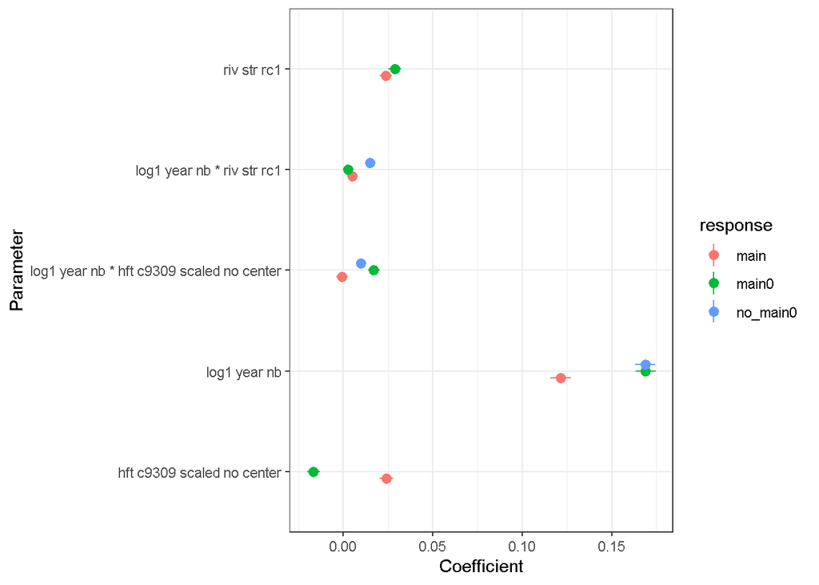

```r
comp_intercept <- compare_models(
  tps_model_for_comp[
    tps_model_for_comp$response == "jaccard_dis_scaled", ]$mod[[1]], effects = "fixed")
comp_intercept %>%
  as_tibble() %>%
  select(Parameter, starts_with("CI_"), starts_with("Coefficient")) %>%
  pivot_longer(-Parameter, names_to = "names", values_to = "values") %>%
  separate(col = names, into  = c("type", "response"), sep = "\\.") %>%
  pivot_wider(names_from = "type", values_from = "values") %>%
  filter(!Parameter %in% "(Intercept)", !str_detect(Parameter, "unitabundance")) %>%
  filter(!response %in% c("species_nb", "log_species_nb", "total_abundance", "total_abundance_scaled")) %>%
  ggplot(
    aes(y = Parameter, x = Coefficient, color = response, xmin = CI_low,
      xmax = CI_high)) +
  geom_pointrange(position = position_dodge(width = .2))
```

- Nestedness:

```r
comp_nestedness <- tps_model_for_comp[tps_model_for_comp$response == "nestedness_scaled", ]$mod[[1]]
anova(comp_nestedness[["main"]], comp_nestedness[["main0"]], comp_nestedness[["no_main0"]])
```

|  | Df | AIC | BIC | logLik | deviance | Chisq | Chi Df | Pr(>Chisq) |
| --- | --- | --- | --- | --- | --- | --- | --- | --- |
| comp_nestedness[["no_main0"]] | 6 | -33380.98 | -33326.97 | 16696.49 | -33392.98 | NA | NA | NA |
| comp_nestedness[["main0"]] | 8 | -33430.59 | -33358.59 | 16723.30 | -33446.59 | 53.61391 | 2 | 2.279756e-12 |
| comp_nestedness[["main"]] | 9 | -34629.14 | -34548.14 | 17323.57 | -34647.14 | 1200.55175 | 1 | 4.627941e-263 |

```r
model_comp_interp_int <- function(resp =NULL, df = modelling_data) {

  ne <- glmmTMB(formula = as.formula(paste0(resp, "~
        log1_year_nb * riv_str_rc1 +
        log1_year_nb * hft_ix_c9309_diff_scaled +
        (0 + log1_year_nb | main_bas/siteid)")),
  data = df
  )

  ne0 <- update(ne,
    formula = as.formula(paste0(resp, "~
        0 + log1_year_nb * riv_str_rc1 +
        log1_year_nb * hft_ix_c9309_diff_scaled +
        (0 + log1_year_nb | main_bas/siteid)"))
  )

  ne0_no_main <- update(ne,
    formula = as.formula(paste0(resp, "~
        0 + log1_year_nb / riv_str_rc1 +
        log1_year_nb / hft_ix_c9309_diff_scaled +
        (0 + log1_year_nb | main_bas/siteid)"))
  )

  list(main = ne, main0 = ne0, no_main0 = ne0_no_main)
}
```

```r
comp_ne <- compare_models(tps_model_for_comp[tps_model_for_comp$response == "nestedness_scaled", ]$mod[[1]], effects = "fixed")

#HERE display plot
```

- Turnover:

```r
tu_comp <- tps_model_for_comp[tps_model_for_comp$response == "turnover_scaled", ]$mod[[1]]
anova(tu_comp[[1]], tu_comp[[2]], tu_comp[[3]])
```

|  | Df | AIC | BIC | logLik | deviance | Chisq | Chi Df | Pr(>Chisq) |
| --- | --- | --- | --- | --- | --- | --- | --- | --- |
| tu_comp[[3]] | 6 | -25596.68 | -25542.68 | 12804.34 | -25608.68 | NA | NA | NA |
| tu_comp[[2]] | 8 | -25789.45 | -25717.45 | 12902.73 | -25805.45 | 196.7701 | 2 | 1.870352e-43 |
| tu_comp[[1]] | 9 | -26276.69 | -26195.68 | 13147.34 | -26294.69 | 489.2314 | 1 | 2.094408e-108 |

```r
aic <- map_dfr(tu_comp, broom.mixed::glance, .id = "name")
round(exp((min(aic$AIC) - aic$AIC)/2), 3)
```

```
#> [1] 1 0 0
```

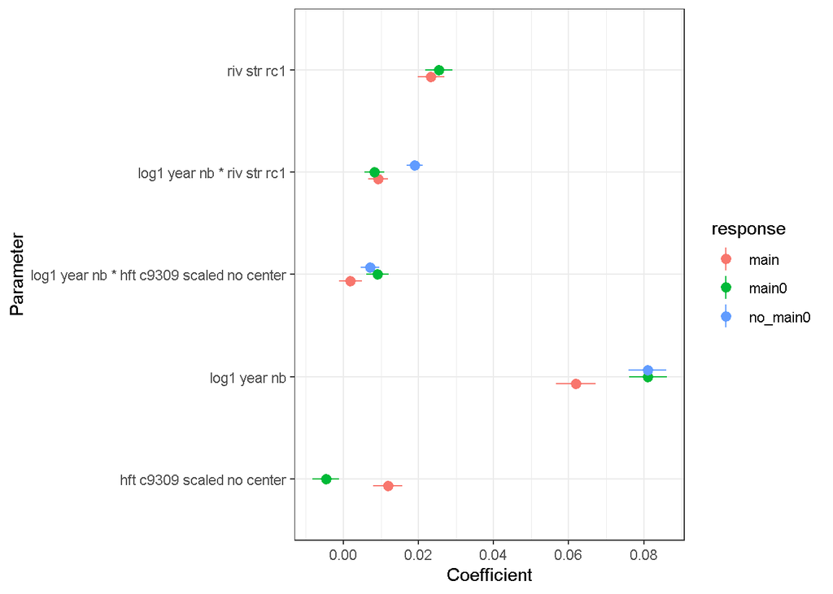

```r
plot_model_comp_coeff(model_list = tu_comp)
```

- Appearance:

```r
appearance_comp <- model_comp_interp_int(resp = "appearance_scaled")
anova(appearance_comp[[1]], appearance_comp[[2]], appearance_comp[[3]])
```

|  | Df | AIC | BIC | logLik | deviance | Chisq | Chi Df | Pr(>Chisq) |
| --- | --- | --- | --- | --- | --- | --- | --- | --- |
| appearance_comp[[3]] | 6 | -80221.84 | -80167.84 | 40116.92 | -80233.84 | NA | NA | NA |
| appearance_comp[[2]] | 8 | -80395.19 | -80323.19 | 40205.59 | -80411.19 | 177.3499 | 2 | 3.082912e-39 |
| appearance_comp[[1]] | 9 | -81044.14 | -80963.13 | 40531.07 | -81062.14 | 650.9488 | 1 | 1.389194e-143 |

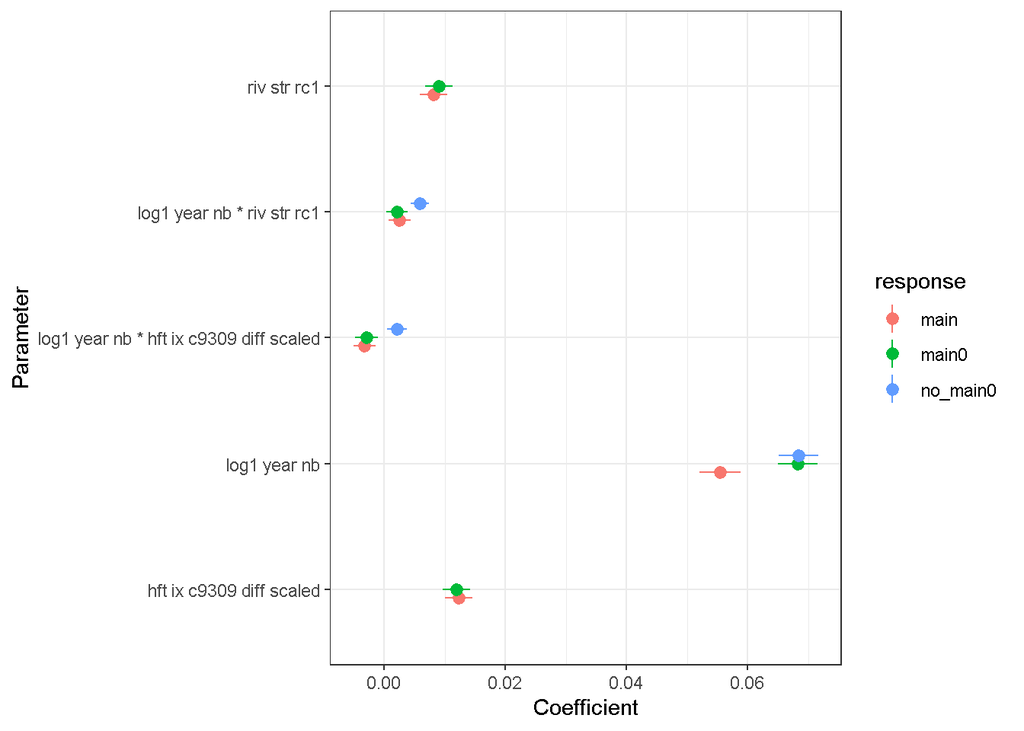

```r
plot_model_comp_coeff(model_list = appearance_comp)
```

## 7.3 Variable distribution

### 7.3.1

```r
skim(modelling_data,
  "jaccard_dis", "turnover", "nestedness", "appearance",
  "disappearance", "hillebrand", "log_chao_richness",
  "log_total_abundance")
```

Table 7.1: Data summary

| Name | modelling_data |
| --- | --- |
| Number of rows | 59904 |
| Number of columns | 44 |
| _______________________ |  |
| Column type frequency: |  |
| numeric | 8 |
| ________________________ |  |
| Group variables | None |

**Variable type: numeric**

| skim_variable | n_missing | complete_rate | mean | sd | p0 | p25 | p50 | p75 | p100 | hist |
| --- | --- | --- | --- | --- | --- | --- | --- | --- | --- | --- |
| jaccard_dis | 0 | 1 | 0.35 | 0.27 | 0.00 | 0.00 | 0.36 | 0.50 | 1.00 | ▇▆▇▃▁ |
| turnover | 0 | 1 | 0.17 | 0.25 | 0.00 | 0.00 | 0.00 | 0.33 | 1.00 | ▇▂▁▁▁ |
| nestedness | 0 | 1 | 0.19 | 0.22 | 0.00 | 0.00 | 0.10 | 0.33 | 0.96 | ▇▂▂▁▁ |
| appearance | 0 | 1 | 0.14 | 0.16 | 0.00 | 0.00 | 0.11 | 0.23 | 0.92 | ▇▃▁▁▁ |
| disappearance | 0 | 1 | 0.11 | 0.14 | 0.00 | 0.00 | 0.05 | 0.18 | 0.91 | ▇▂▁▁▁ |
| hillebrand | 0 | 1 | 0.67 | 0.33 | 0.00 | 0.41 | 0.77 | 0.99 | 1.00 | ▂▂▂▂▇ |
| log_chao_richness | 0 | 1 | 1.32 | 0.86 | 0.00 | 0.67 | 1.28 | 1.97 | 4.45 | ▇▇▆▁▁ |
| log_total_abundance | 0 | 1 | 4.17 | 1.74 | -4.61 | 3.04 | 4.19 | 5.40 | 11.60 | ▁▁▇▃▁ |

### 7.3.2

## 7.4 Analysis

### 7.4.1 Rigal method result

#### 7.4.1.1 Trends according to Rigal method

```r
ti <- map_dfr(rigal_trends, ~tabyl_df(x = .x, group = "direction"),
  .id = "response"
)
ti %>%
  filter(direction != "Total", response %in% clust_var) %>%
  select(response, direction, percent) %>%
  mutate(response = str_replace_all(response, get_var_replacement())) %>%
  pivot_wider(names_from = "direction", values_from = "percent") %>%
  kable() %>%
  kable_styling(bootstrap_options = c("striped", "bordered", "hover"))
```

| response |
| --- |

```r
ti <- map_dfr(rigal_trends, ~tabyl_df(x = .x, group = "shape_class"),
  .id = "response"
)

ti %>%
  filter(shape_class != "Total") %>%
  select(response, shape_class, percent) %>%
  mutate(response = str_replace_all(response, get_var_replacement())) %>%
  pivot_wider(names_from = "shape_class", values_from = "percent") %>%
  kable() %>%
  kable_styling(bootstrap_options = c("striped", "bordered", "hover"))
```

| response | stable_constant | increase_constant | decrease_constant | stable_convex | stable_concave | decrease_decelerated | increase_accelerated | decrease_accelerated | increase_decelerated | NA_constant |
| --- | --- | --- | --- | --- | --- | --- | --- | --- | --- | --- |
| rigal_trends_277cc575 | 73.0% | 8.7% | 6.3% | 6.1% | 3.9% | 1.2% | 0.8% | 0.1% | 0.1% | NA |
| rigal_trends_af4311e4 | 69.7% | 10.0% | 7.2% | 4.8% | 6.3% | 0.3% | 0.2% | 0.4% | 1.1% | 0.0% |
| rigal_trends_36645234 | 70.1% | 9.6% | 5.0% | 4.5% | 6.1% | 0.9% | 0.8% | 0.3% | 1.1% | 1.8% |
| rigal_trends_9f1fe847 | 68.8% | 9.4% | 4.7% | 3.5% | 6.9% | 0.7% | 0.7% | 0.3% | 1.0% | 4.1% |
| rigal_trends_c8b5007b | 73.7% | 8.1% | 5.2% | 4.6% | 4.5% | 1.0% | 0.9% | 0.1% | 0.6% | 1.3% |
| rigal_trends_55ef4dbb | 70.9% | 8.8% | 5.2% | 4.1% | 5.4% | 0.6% | 0.8% | 0.2% | 0.6% | 3.5% |
| rigal_trends_3ce705fd | 72.2% | 7.8% | 5.2% | 4.2% | 5.1% | 0.7% | 0.6% | 0.1% | 0.5% | 3.5% |
| rigal_trends_5a9ad964 | 77.5% | 5.4% | 4.6% | 3.3% | 4.3% | 0.4% | 0.4% | 0.1% | 0.4% | 3.5% |
| rigal_trends_26f536d5 | 54.8% | 0.3% | 21.8% | 14.6% | 0.9% | 4.8% | NA | 0.6% | 0.3% | 1.8% |
| rigal_trends_70059047 | 58.4% | 0.3% | 21.8% | 12.3% | 1.0% | 3.3% | NA | 0.7% | 0.3% | 1.8% |
| rigal_trends_011bea23 | 58.8% | 0.8% | 7.5% | 9.2% | 4.4% | 3.8% | NA | 1.2% | 1.7% | 12.6% |
| rigal_trends_e1ce80e1 | 59.7% | 0.5% | 19.5% | 12.3% | 1.4% | 4.1% | 0.0% | 1.2% | 0.1% | 1.2% |
| rigal_trends_41c42c70 | 56.0% | 22.0% | 0.3% | 0.8% | 11.5% | NA | 0.8% | NA | 3.3% | 5.3% |
| rigal_trends_347064a0 | 58.8% | 16.8% | 0.5% | 0.9% | 8.7% | NA | 1.2% | 0.0% | 1.8% | 11.4% |
| rigal_trends_4bb7751a | 52.7% | 12.5% | 0.2% | 1.1% | 7.5% | NA | 0.6% | NA | 2.1% | 23.3% |
| rigal_trends_044f0e27 | 73.7% | 6.7% | 5.6% | 4.1% | 4.7% | 0.7% | 0.5% | 0.2% | 0.5% | 3.5% |
| rigal_trends_8b395af7 | 70.0% | 9.0% | 5.6% | 4.0% | 5.7% | 0.6% | 0.6% | 0.2% | 0.7% | 3.5% |
| rigal_trends_350db00d | 72.1% | 7.7% | 5.2% | 3.7% | 5.6% | 0.6% | 0.5% | 0.3% | 0.8% | 3.5% |
| rigal_trends_83e4886a | 52.8% | 21.8% | 0.3% | 0.7% | 14.1% | NA | 0.6% | NA | 4.5% | 5.3% |
| rigal_trends_59f701b2 | 71.6% | 11.3% | 0.5% | 1.0% | 7.7% | NA | 0.7% | NA | 1.3% | 5.9% |
| rigal_trends_34b431b9 | 48.1% | 10.5% | 0.2% | 1.0% | 5.3% | NA | 0.6% | 0.0% | 1.1% | 33.2% |

#### 7.4.1.2 Comparison of our results with previous studies (rigal method)

```r
tar_load(rigal_slp_df)
```

```r
knitr::opts_chunk$set(eval = FALSE)
```

```r
ti <- expand.grid(
  resp1 = unique(slope$response),
  resp2 = unique(slope$response)
  ) %>%
  filter(resp2 != resp1) %>%
  filter(
    resp1 %in% c("chao_richness", "species_nb", "log_species_nb",
      "total_abundance", "log_total_abundance")) %>%
  mutate_all(as.character) %>%
  arrange(resp1)

test <- map2(ti$resp1, ti$resp2,
  function(x, y) {
    bi <- slope %>%
      filter(response %in% c(x, y)) %>%
      select(siteid, response, linear_slope) %>%
      pivot_wider(names_from = "response", values_from = "linear_slope")

    return(bi)
  }
)

p_trends_trends <- map(test, function(x) {
  l <- colnames(x)
  x %>%
    ggplot(aes(x = !!sym(l[2]), y = !!sym(l[3]))) +
    geom_point() +
    geom_smooth(method = "loess") +
    labs(
      x = get_var_replacement()[l[2]],
      y = get_var_replacement()[l[3]]
    )
})
names(p_trends_trends) <- map_chr(test, ~colnames(.x)[2])
```

```r
plot_grid(
  plotlist = p_trends_trends[names(p_trends_trends) %in% "log_species_nb"],
  ncol = 3
)
```

#### 7.4.1.3 Maps

```r
rigal_trends_df_loc <- filtered_dataset$location %>%
  left_join(rigal_trends_df, by = "siteid") %>%
  st_as_sf(coords = c("longitude", "latitude"),
  crs = 4326)
```

## 7.5 Reproducibility

**Reproducibility receipt**

```r
## datetime
Sys.time()

## repository
if(requireNamespace('git2r', quietly = TRUE)) {
  git2r::repository()
} else {
  c(
    system2("git", args = c("log", "--name-status", "-1"), stdout = TRUE),
    system2("git", args = c("remote", "-v"), stdout = TRUE)
  )
}

## session info
sessionInfo()
```